# 1. Introduction

**Projet :** Prévision des Revenus de Ventes de Smartphones  
**Auteur :** Salma Ouadi

**Objectif :**

1. Comprendre les tendances et les structures sous-jacentes des données.
2. Identifier les variables clés influençant les revenus.
3. Préparer les données pour la phase de modélisation dans un second temps.

**Contenu :**

- Exploration et nettoyage des données brutes.
- Analyse des relations entre les variables et identification des facteurs déterminants.
- Préparation des données pour une modélisation prédictive efficace.

# 2. Importation des bibliothèques et configuration

```python
import pandas as pd
import numpy as np
import matplotlib.pyplot as plt
import seaborn as sns
import os
from tabulate import tabulate
```

```python
from src.data_processing import (
    load_data,          # Chargement des données
    describe_data,      # Description des données (types, aperçu)
    clean_data,         # Nettoyage des données
    summarize_data,     # Résumés statistiques avant/après nettoyage
    transform_to_long,  # Transformation des données au format long
    calculate_city_revenue,  # Calcul des revenus moyens par ville
    compute_correlation_matrix,  # Calcul de la matrice de corrélation
    save_cleaned_data   # Sauvegarde des données nettoyées
)
```

```python
# Configuration des options d'affichage
pd.set_option('display.max_columns', None)
pd.set_option('display.max_rows', 100)
sns.set(style="whitegrid")
```

# 3. Chargement des données et aperçu général

## Description des colonnes

- **Unnamed: 0** : Représente la date des ventes (cette colonne sera convertie au format `datetime` pour une meilleure manipulation).
- **marketing_score** : Indique l'intensité et l'efficacité des actions marketing mises en œuvre (campagnes, promotions).
- **competition_index** : Mesure le niveau de pression concurrentielle dans le marché.
- **customer_satisfaction** : Score représentant la satisfaction des clients (mesuré sur une échelle prédéfinie).
- **purchasing_power_index** : Indice du pouvoir d'achat dans la région où la vente a eu lieu.
- **weather_condition** : État des conditions météorologiques pour un jour donné (exemple : "Good", "Bad", "Moderate").
- **tech_event** : Variable binaire ou catégorique indiquant s'il s'agit d'un jour avec un événement technologique significatif.
- **5g_phase** : Phase de déploiement de la technologie 5G (par exemple, "Pre-5G", "Mature-5G").
- **store_traffic** : Score représentant l'affluence des clients dans les magasins.
- **public_transport** : Qualité ou état des transports publics locaux (exemple : "Hub", "Good", "Limited").
- **city** : Ville où la transaction ou l'événement de vente a été enregistré.
- **jPhone_Pro_revenue** : Revenus générés par le modèle jPhone Pro sur une période donnée.
- **Kaggle_Pixel_5_revenue** : Revenus générés par le modèle Kaggle Pixel 5 sur une période donnée.
- **Planet_SX_revenue** : Revenus générés par le modèle Planet SX sur une période donnée.

```python
# Chargement des données
file_path = "data/raw/telecom_sales_data.csv"
data = load_data(file_path)

# Aperçu rapide des données
print("Aperçu des premières lignes des données brutes :")
display(data.head())

# Dimensions du dataset
print(f"Nombre de lignes : {data.shape[0]}, Nombre de colonnes : {data.shape[1]}")
```

```
Données chargées depuis data/raw/telecom_sales_data.csv.
Aperçu des premières lignes des données brutes :
```

|  | Unnamed: 0 | marketing_score | competition_index | customer_satisfaction | purchasing_power_index | weather_condition | tech_event | 5g_phase | store_traffic | public_transport | city | jPhone_Pro_revenue | Kaggle_Pixel_5_revenue | Planet_SX_revenue |
| --- | --- | --- | --- | --- | --- | --- | --- | --- | --- | --- | --- | --- | --- | --- |
| 0 | 2019-01-01 | 100.00 | 50.00 | 85.0 | 120.00 | Bad | NaN | Pre-5G | 0.02 | Hub | Paris | 122182.54 | 68709.20 | 36032.11 |
| 1 | 2019-01-02 | 100.09 | 50.52 | 85.0 | 120.09 | Good | NaN | Pre-5G | 1.08 | Good | Paris | 146473.79 | 73935.56 | 44180.21 |
| 2 | 2019-01-03 | 100.18 | 51.04 | 85.0 | 120.17 | Moderate | NaN | Pre-5G | -0.24 | Limited | Paris | 129647.90 | 75375.54 | 41112.52 |
| 3 | 2019-01-04 | 100.27 | 51.56 | 85.0 | 120.26 | Moderate | NaN | Pre-5G | -0.13 | Poor | Paris | 137621.01 | 85213.00 | 46222.99 |
| 4 | 2019-01-05 | 100.36 | 52.08 | 85.0 | 120.34 | Bad | NaN | Pre-5G | 0.06 | Limited | Paris | 194936.87 | 89281.49 | 38312.08 |

```
Nombre de lignes : 17536, Nombre de colonnes : 14
```

```python
# Types de données
types_df = pd.DataFrame({"Colonne": data.columns, "Type de données": data.dtypes.values})
print("\nTypes de données :\n")
print(tabulate(types_df, headers="keys", tablefmt="grid", showindex=False))
```

```
Types de données :

+------------------------+-------------------+
| Colonne                | Type de données   |
+========================+===================+
| Unnamed: 0             | object            |
+------------------------+-------------------+
| marketing_score        | float64           |
+------------------------+-------------------+
| competition_index      | float64           |
+------------------------+-------------------+
| customer_satisfaction  | float64           |
+------------------------+-------------------+
| purchasing_power_index | float64           |
+------------------------+-------------------+
| weather_condition      | object            |
+------------------------+-------------------+
| tech_event             | object            |
+------------------------+-------------------+
| 5g_phase               | object            |
+------------------------+-------------------+
| store_traffic          | float64           |
+------------------------+-------------------+
| public_transport       | object            |
+------------------------+-------------------+
| city                   | object            |
+------------------------+-------------------+
| jPhone_Pro_revenue     | float64           |
+------------------------+-------------------+
| Kaggle_Pixel_5_revenue | float64           |
+------------------------+-------------------+
| Planet_SX_revenue      | float64           |
+------------------------+-------------------+
```

# 4. Statistiques descriptives

### Explications des colonnes des statistiques descriptives :

#### Pour les variables numériques :

- **Colonne** : Nom de la colonne analysée.
- **count** : Nombre total de valeurs non manquantes (observations) dans la colonne.
- **mean** : Moyenne (valeur moyenne) des données.
- **std** : Écart-type, qui mesure la dispersion des valeurs par rapport à la moyenne.
- **min** : Valeur minimale dans la colonne.
- **25% (1er Quartile)** : La valeur en dessous de laquelle se trouvent 25 % des données.
- **50% (Médiane)** : La valeur médiane (valeur centrale) des données.
- **75% (3e Quartile)** : La valeur en dessous de laquelle se trouvent 75 % des données.
- **max** : Valeur maximale dans la colonne.

#### Pour les variables catégoriques :

- **Colonne** : Nom de la colonne analysée.
- **count** : Nombre total de valeurs non manquantes (observations) dans la colonne.
- **unique** : Nombre de valeurs uniques présentes dans la colonne.
- **top** : Valeur la plus fréquente (mode) dans la colonne.
- **freq** : Fréquence d'apparition de la valeur la plus fréquente.

```python
# Générer les statistiques descriptives
numeric_desc, categorical_desc = describe_data(data)

# Affichage des statistiques numériques
print("\nStatistiques descriptives des variables numériques :\n")
print(tabulate(numeric_desc, headers="keys", tablefmt="grid", showindex=False))

# Affichage des statistiques catégoriques
print("\nStatistiques descriptives des variables catégoriques :\n")
print(tabulate(categorical_desc, headers="keys", tablefmt="grid", showindex=False))
```

```
Statistiques descriptives des variables numériques :

+------------------------+---------+--------------+--------------+---------+----------+----------+-----------+-----------+
| Colonne                |   count |         mean |          std |     min |      25% |      50% |       75% |       max |
+========================+=========+==============+==============+=========+==========+==========+===========+===========+
| marketing_score        |   17273 |    88.7371   |    14.7884   |   40.9  |    81.01 |    89.82 |     98.29 |    126.81 |
+------------------------+---------+--------------+--------------+---------+----------+----------+-----------+-----------+
| competition_index      |   17100 |    20.4614   |    13.6781   |    4.74 |    11.44 |    16.87 |     24.96 |     64.41 |
+------------------------+---------+--------------+--------------+---------+----------+----------+-----------+-----------+
| customer_satisfaction  |   17370 |    72.2799   |     9.16044  |   48.96 |    69.5  |    72.43 |     76.74 |     89.77 |
+------------------------+---------+--------------+--------------+---------+----------+----------+-----------+-----------+
| purchasing_power_index |   17193 |    98.7692   |    11.9185   |   75    |    91.13 |    97.49 |    105    |    125    |
+------------------------+---------+--------------+--------------+---------+----------+----------+-----------+-----------+
| store_traffic          |   17390 |     0.195773 |     0.549067 |   -1.87 |    -0.17 |     0.19 |      0.57 |      2.66 |
+------------------------+---------+--------------+--------------+---------+----------+----------+-----------+-----------+
| jPhone_Pro_revenue     |   16411 | 83883.2      | 56860.1      |    0    | 45667    | 70835.8  | 104173    | 536860    |
+------------------------+---------+--------------+--------------+---------+----------+----------+-----------+-----------+
| Kaggle_Pixel_5_revenue |   16686 | 40562.9      | 26659.6      | 1576.18 | 22463.8  | 33985    |  49957.4  | 239736    |
+------------------------+---------+--------------+--------------+---------+----------+----------+-----------+-----------+
| Planet_SX_revenue      |   16383 | 21856.5      | 14219.6      | 1066.71 | 12326.1  | 18288.8  |  26804    | 103251    |
+------------------------+---------+--------------+--------------+---------+----------+----------+-----------+-----------+

Statistiques descriptives des variables catégoriques :

+-------------------+---------+----------+--------------+--------+
| Colonne           |   count |   unique | top          |   freq |
+===================+=========+==========+==============+========+
| Unnamed: 0        |   17536 |     2192 | 2019-01-01   |      8 |
+-------------------+---------+----------+--------------+--------+
| weather_condition |   17467 |        3 | Moderate     |   7599 |
+-------------------+---------+----------+--------------+--------+
| tech_event        |      66 |        2 | Major Launch |     48 |
+-------------------+---------+----------+--------------+--------+
| 5g_phase          |   17245 |        4 | Mature-5G    |   7583 |
+-------------------+---------+----------+--------------+--------+
| public_transport  |   17436 |        4 | Hub          |   8617 |
+-------------------+---------+----------+--------------+--------+
| city              |   17536 |        8 | Paris        |   2192 |
+-------------------+---------+----------+--------------+--------+
```

# 5. Analyse des valeurs manquantes

```python
from src.data_processing import clean_data

# Chargement des données
file_path = "data/raw/telecom_sales_data.csv"
data = pd.read_csv(file_path)

# Vérification des valeurs manquantes AVANT nettoyage
missing_data_raw = data.isnull().sum().reset_index()
missing_data_raw.columns = ['Colonne', 'Valeurs manquantes (Avant)']
missing_data_raw['Pourcentage (Avant)'] = (missing_data_raw['Valeurs manquantes (Avant)'] / len(data) * 100).round(2)

# Nettoyage des données
data_cleaned = clean_data(data)

# Vérification des valeurs manquantes APRES nettoyage
missing_data_after = data_cleaned.isnull().sum().reset_index()
missing_data_after.columns = ['Colonne', 'Valeurs manquantes (Après)']
missing_data_after['Pourcentage (Après)'] = (missing_data_after['Valeurs manquantes (Après)'] / len(data_cleaned) * 100).round(2)

# Combiner les tableaux avant/après
combined_missing_data = pd.merge(missing_data_raw, missing_data_after, on="Colonne")
print("\nValeurs manquantes par colonne (avant et après nettoyage) :\n")
print(tabulate(combined_missing_data, headers="keys", tablefmt="fancy_grid"))
```

```
Nettoyage des données terminé.

Valeurs manquantes par colonne (avant et après nettoyage) :

╒════╤════════════════════════╤══════════════════════════════╤═══════════════════════╤══════════════════════════════╤═══════════════════════╕
│    │ Colonne                │   Valeurs manquantes (Avant) │   Pourcentage (Avant) │   Valeurs manquantes (Après) │   Pourcentage (Après) │
╞════╪════════════════════════╪══════════════════════════════╪═══════════════════════╪══════════════════════════════╪═══════════════════════╡
│  0 │ Unnamed: 0             │                            0 │                  0    │                            0 │                     0 │
├────┼────────────────────────┼──────────────────────────────┼───────────────────────┼──────────────────────────────┼───────────────────────┤
│  1 │ marketing_score        │                          263 │                  1.5  │                            0 │                     0 │
├────┼────────────────────────┼──────────────────────────────┼───────────────────────┼──────────────────────────────┼───────────────────────┤
│  2 │ competition_index      │                          436 │                  2.49 │                            0 │                     0 │
├────┼────────────────────────┼──────────────────────────────┼───────────────────────┼──────────────────────────────┼───────────────────────┤
│  3 │ customer_satisfaction  │                          166 │                  0.95 │                            0 │                     0 │
├────┼────────────────────────┼──────────────────────────────┼───────────────────────┼──────────────────────────────┼───────────────────────┤
│  4 │ purchasing_power_index │                          343 │                  1.96 │                            0 │                     0 │
├────┼────────────────────────┼──────────────────────────────┼───────────────────────┼──────────────────────────────┼───────────────────────┤
│  5 │ weather_condition      │                           69 │                  0.39 │                            0 │                     0 │
├────┼────────────────────────┼──────────────────────────────┼───────────────────────┼──────────────────────────────┼───────────────────────┤
│  6 │ tech_event             │                        17470 │                 99.62 │                            0 │                     0 │
├────┼────────────────────────┼──────────────────────────────┼───────────────────────┼──────────────────────────────┼───────────────────────┤
│  7 │ 5g_phase               │                          291 │                  1.66 │                            0 │                     0 │
├────┼────────────────────────┼──────────────────────────────┼───────────────────────┼──────────────────────────────┼───────────────────────┤
│  8 │ store_traffic          │                          146 │                  0.83 │                            0 │                     0 │
├────┼────────────────────────┼──────────────────────────────┼───────────────────────┼──────────────────────────────┼───────────────────────┤
│  9 │ public_transport       │                          100 │                  0.57 │                            0 │                     0 │
├────┼────────────────────────┼──────────────────────────────┼───────────────────────┼──────────────────────────────┼───────────────────────┤
│ 10 │ city                   │                            0 │                  0    │                            0 │                     0 │
├────┼────────────────────────┼──────────────────────────────┼───────────────────────┼──────────────────────────────┼───────────────────────┤
│ 11 │ jPhone_Pro_revenue     │                         1125 │                  6.42 │                            0 │                     0 │
├────┼────────────────────────┼──────────────────────────────┼───────────────────────┼──────────────────────────────┼───────────────────────┤
│ 12 │ Kaggle_Pixel_5_revenue │                          850 │                  4.85 │                            0 │                     0 │
├────┼────────────────────────┼──────────────────────────────┼───────────────────────┼──────────────────────────────┼───────────────────────┤
│ 13 │ Planet_SX_revenue      │                         1153 │                  6.58 │                            0 │                     0 │
╘════╧════════════════════════╧══════════════════════════════╧═══════════════════════╧══════════════════════════════╧═══════════════════════╛
```

# 6. Résumés statistiques avant et après nettoyage

```python
# Résumé statistique avant et après nettoyage
data_raw = load_data("data/raw/telecom_sales_data.csv")
numeric_summary_before, numeric_summary_after = summarize_data(data_raw, data_cleaned)

# Affichage des résumés
print("\nRésumé statistique AVANT nettoyage :\n")
print(tabulate(numeric_summary_before, headers='keys', tablefmt='fancy_grid'))
print("\nRésumé statistique APRES nettoyage :\n")
print(tabulate(numeric_summary_after, headers='keys', tablefmt='fancy_grid'))

# Calcul du nombre de lignes supprimées
lines_removed = len(data_raw) - len(data_cleaned)
percentage_removed = round(lines_removed / len(data_raw) * 100, 2)
print(f"\nNombre total de lignes supprimées : {lines_removed} (sur {len(data_raw)} lignes initiales, soit {percentage_removed}%).")
```

```
Données chargées depuis data/raw/telecom_sales_data.csv.

Résumé statistique AVANT nettoyage :

╒════╤════════════════════════╤═════════════════════╤═══════════╤══════════════╤═════════╤═══════════╤═══════════╕
│    │ Colonne                │   Nombre de valeurs │   Moyenne │   Écart-type │     Min │   Médiane │       Max │
╞════╪════════════════════════╪═════════════════════╪═══════════╪══════════════╪═════════╪═══════════╪═══════════╡
│  0 │ marketing_score        │               17273 │     88.74 │        14.79 │   40.9  │     89.82 │    126.81 │
├────┼────────────────────────┼─────────────────────┼───────────┼──────────────┼─────────┼───────────┼───────────┤
│  1 │ competition_index      │               17100 │     20.46 │        13.68 │    4.74 │     16.87 │     64.41 │
├────┼────────────────────────┼─────────────────────┼───────────┼──────────────┼─────────┼───────────┼───────────┤
│  2 │ customer_satisfaction  │               17370 │     72.28 │         9.16 │   48.96 │     72.43 │     89.77 │
├────┼────────────────────────┼─────────────────────┼───────────┼──────────────┼─────────┼───────────┼───────────┤
│  3 │ purchasing_power_index │               17193 │     98.77 │        11.92 │   75    │     97.49 │    125    │
├────┼────────────────────────┼─────────────────────┼───────────┼──────────────┼─────────┼───────────┼───────────┤
│  4 │ store_traffic          │               17390 │      0.2  │         0.55 │   -1.87 │      0.19 │      2.66 │
├────┼────────────────────────┼─────────────────────┼───────────┼──────────────┼─────────┼───────────┼───────────┤
│  5 │ jPhone_Pro_revenue     │               16411 │  83883.2  │     56860.1  │    0    │  70835.8  │ 536860    │
├────┼────────────────────────┼─────────────────────┼───────────┼──────────────┼─────────┼───────────┼───────────┤
│  6 │ Kaggle_Pixel_5_revenue │               16686 │  40562.9  │     26659.6  │ 1576.18 │  33985    │ 239736    │
├────┼────────────────────────┼─────────────────────┼───────────┼──────────────┼─────────┼───────────┼───────────┤
│  7 │ Planet_SX_revenue      │               16383 │  21856.5  │     14219.6  │ 1066.71 │  18288.8  │ 103251    │
╘════╧════════════════════════╧═════════════════════╧═══════════╧══════════════╧═════════╧═══════════╧═══════════╛

Résumé statistique APRES nettoyage :

╒════╤════════════════════════╤═════════════════════╤═══════════╤══════════════╤═════════╤═══════════╤═══════════╕
│    │ Colonne                │   Nombre de valeurs │   Moyenne │   Écart-type │     Min │   Médiane │       Max │
╞════╪════════════════════════╪═════════════════════╪═══════════╪══════════════╪═════════╪═══════════╪═══════════╡
│  0 │ marketing_score        │               14606 │     88.7  │        14.67 │   40.9  │     89.57 │    126.81 │
├────┼────────────────────────┼─────────────────────┼───────────┼──────────────┼─────────┼───────────┼───────────┤
│  1 │ competition_index      │               14606 │     20.57 │        13.56 │    4.74 │     17.17 │     64.41 │
├────┼────────────────────────┼─────────────────────┼───────────┼──────────────┼─────────┼───────────┼───────────┤
│  2 │ customer_satisfaction  │               14606 │     72.3  │         9.09 │   48.96 │     72.4  │     89.77 │
├────┼────────────────────────┼─────────────────────┼───────────┼──────────────┼─────────┼───────────┼───────────┤
│  3 │ purchasing_power_index │               14606 │     98.8  │        11.78 │   75    │     97.8  │    125    │
├────┼────────────────────────┼─────────────────────┼───────────┼──────────────┼─────────┼───────────┼───────────┤
│  4 │ store_traffic          │               14606 │      0.19 │         0.55 │   -1.87 │      0.19 │      2.66 │
├────┼────────────────────────┼─────────────────────┼───────────┼──────────────┼─────────┼───────────┼───────────┤
│  5 │ jPhone_Pro_revenue     │               14606 │  83443.9  │     56633.5  │    0    │  70504.8  │ 536860    │
├────┼────────────────────────┼─────────────────────┼───────────┼──────────────┼─────────┼───────────┼───────────┤
│  6 │ Kaggle_Pixel_5_revenue │               14606 │  40366.5  │     26585.1  │ 1576.18 │  33735.4  │ 222601    │
├────┼────────────────────────┼─────────────────────┼───────────┼──────────────┼─────────┼───────────┼───────────┤
│  7 │ Planet_SX_revenue      │               14606 │  21738.7  │     14126    │ 1066.71 │  18184    │ 103251    │
╘════╧════════════════════════╧═════════════════════╧═══════════╧══════════════╧═════════╧═══════════╧═══════════╛

Nombre total de lignes supprimées : 2930 (sur 17536 lignes initiales, soit 16.71%).
```

## Analyse des données avant et après nettoyage

### État des données avant et après nettoyage

- **Avant nettoyage** : Des valeurs manquantes significatives, notamment :
  - `tech_event` : **99.62%** de données manquantes.
  - Revenus (`jPhone_Pro_revenue`, `Kaggle_Pixel_5_revenue`, `Planet_SX_revenue`) : entre **4.85%** et **6.58%** de données manquantes.
- **Après nettoyage** : Toutes les valeurs manquantes ont été corrigées.

### Impact du nettoyage

- **Données supprimées** : **2930 lignes** supprimées (**16.71%**) pour garantir l'intégrité des colonnes critiques.
- **Distributions ajustées** :
  - Réduction des écarts-types, reflétant une diminution des variabilités inutiles.
  - Nombre uniforme de valeurs (**14606**) dans toutes les colonnes numériques.

Le nettoyage a supprimé les données inutilisables, amélioré la cohérence et assuré une base fiable pour les analyses à venir.

# 7. Visualisations et analyses avancées

## 7.1 Relation entre l'intensité marketing et les revenus

### Observations

Ce graphique illustre la corrélation entre l'intensité marketing (`marketing_score`) et les revenus pour chaque modèle de smartphone. Les lignes de régression montrent que **jPhone_Pro** répond le mieux aux efforts marketing, tandis que **Planet_SX** présente une réponse plus modérée.

### Utilité

Cette analyse permet d'optimiser l'allocation des budgets marketing en identifiant les modèles les plus réactifs et en adaptant les stratégies selon leur performance.

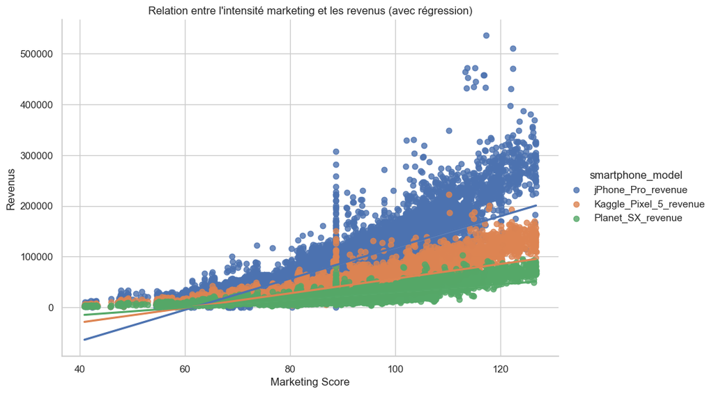

```python
# Transformation en format long
data_long = transform_to_long(data_cleaned)

# Visualisation de la relation entre marketing_score et revenues
plt.figure(figsize=(10, 6))
sns.lmplot(x="marketing_score", y="revenue", hue="smartphone_model", data=data_long, height=6, aspect=1.5)
plt.title("Relation entre l'intensité marketing et les revenus (avec régression)")
plt.xlabel("Marketing Score")
plt.ylabel("Revenus")
plt.show()
```

## 7.2 Revenus moyens par ville et par modèle de smartphone

### Observations

Ce graphique compare les revenus moyens des modèles (`jPhone_Pro`, `Kaggle_Pixel_5`, et `Planet_SX`) dans différentes villes. **jPhone_Pro** se distingue comme le modèle le plus performant, notamment à Paris et Lyon, tandis que les autres modèles présentent des performances plus homogènes.

### Utilité

Cette visualisation aide à identifier les villes clés pour des campagnes marketing ciblées et à ajuster les stratégies selon les performances locales.

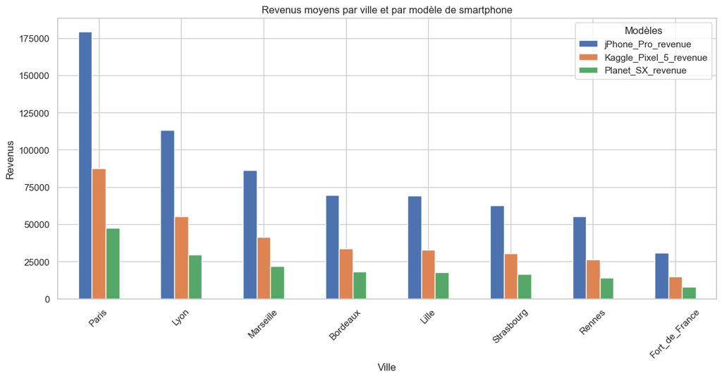

```python
# Calcul des revenus moyens par ville
city_revenue = calculate_city_revenue(data_cleaned)

# Visualisation
city_revenue.drop(columns=['Total_Revenue']).plot(kind='bar', figsize=(14, 6))
plt.title("Revenus moyens par ville et par modèle de smartphone")
plt.ylabel("Revenus")
plt.xlabel("Ville")
plt.legend(title="Modèles")
plt.xticks(rotation=45)
plt.show()
```

## 7.3 Matrice de corrélation des variables numériques

### Observations

La matrice de corrélation permet de visualiser les relations linéaires entre les variables numériques. Les corrélations élevées sont particulièrement visibles entre :

- **Revenus des modèles** : Les revenus des trois modèles de smartphone sont fortement corrélés, suggérant des dynamiques de marché similaires.
- **Marketing et revenus** : Une forte corrélation existe entre le `marketing_score` et les revenus, confirmant l'importance des efforts marketing.

### Utilité

Cette matrice est essentielle pour :

1. Identifier les variables ayant le plus d'influence sur les revenus.
2. Éviter la multicolinéarité dans les futurs modèles prédictifs.
3. Comprendre les relations globales entre les indicateurs clés.

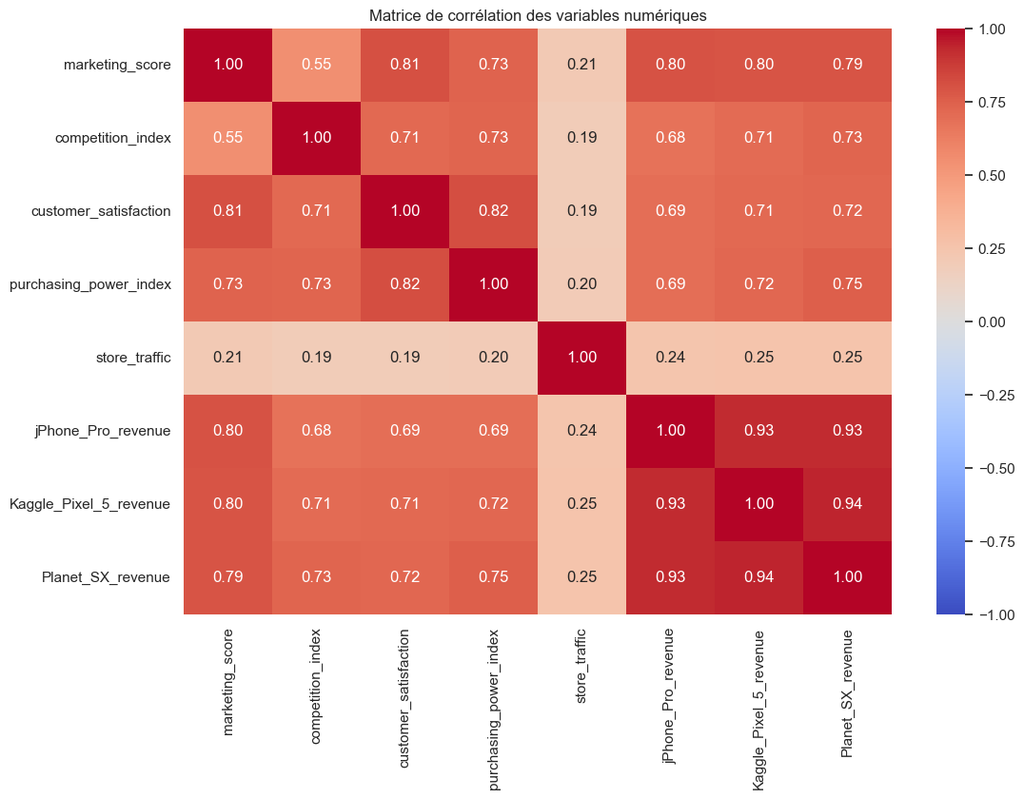

```python
# Calcul de la matrice de corrélation
correlation_matrix = compute_correlation_matrix(data_cleaned)

# Visualisation
plt.figure(figsize=(12, 8))
sns.heatmap(correlation_matrix, annot=True, fmt=".2f", cmap="coolwarm", vmin=-1, vmax=1)
plt.title("Matrice de corrélation des variables numériques")
plt.show()
```

# 8. Sauvegarde des données nettoyées

Les données nettoyées sont sauvegardées dans un fichier CSV dans le dossier `data/processed`. Ce fichier sera utilisé dans le Notebook 2 pour les étapes de modélisation.

```python
# Sauvegarde des données nettoyées
output_dir = "data/processed"
file_name = "cleaned_data.csv"
save_cleaned_data(data_cleaned, output_dir=output_dir, file_name=file_name)
print(f"Les données nettoyées ont été sauvegardées dans : {os.path.join(output_dir, file_name)}")
```

```
Données nettoyées sauvegardées dans : data/processed/cleaned_data.csv
Les données nettoyées ont été sauvegardées dans : data/processed/cleaned_data.csv
```

# 9. Préparation des insights pour la modélisation

### 2. Insights principaux :

- **Revenus par modèle :**
  - **jPhone Pro** domine en termes de revenus, avec une forte dispersion indiquant une variabilité dans les performances.
  - **Kaggle Pixel 5** affiche des revenus moyens, mais plus homogènes, ce qui en fait un modèle stable.
  - **Planet SX** a les revenus les plus faibles, mais une performance constante.
- **Variabilité géographique :**
  - Les villes comme **Paris** et **Lyon** contribuent significativement aux revenus totaux.
  - Les différences de pouvoir d'achat et de trafic en magasin influencent directement les revenus par région.

### 4. Étapes préparatoires pour la modélisation :

- Sélection des variables les plus influentes pour limiter la complexité des modèles tout en optimisant leurs performances.
- Construction de nouvelles variables dérivées (par exemple, indicateurs saisonniers ou régionaux).
- Garantir l'équilibre des données à travers les modèles pour éviter des biais dans les prédictions.

**Conclusion :** Cette analyse approfondie des données brutes fournit une base robuste et interprétable pour les prochaines étapes de modélisation. Les insights extraits orienteront les choix méthodologiques et stratégiques pour maximiser la pertinence des prédictions.